# Heart Disease Predictive Modelling in R

Executive Summary

Author

Ady Lam

Published

March 20, 2025

**Github Repo Link**

[Ady’s Github Repo URL for her Final Project - dun dun dun!!!](https://github.com/stat301-2-2025-winter/final-project-2-adylam00.git)

## Introduction

The goal of this project was to develop a classification model to predict whether individuals have experienced heart disease or a heart attack, based on binary outcome variables about their health-related risk behaviours and chronic health conditions.

## Methods

### Data Preprocessing & Splitting

- The original dataset of 253,680 observations was filtered to create a balanced dataset by including all ‘yes’ cases (heart disease/attack) and randomly selecting an equal number of ‘no’ cases. The data was split into 80% training and 20% testing sets, with stratification to ensure both sets had a similar distribution of the outcome variable.

### Models & Parameters

The model types I fit are listed below, along with the parameters that I tuned in brackets (where applicable, with explanations of what these parameters mean). Each model was run with a basic and a more complex recipe apart from the null and Naive Bayes models.

Six model types were tested, with tuning parameters optimized where applicable:

1. Null/Naive Bayes – Baseline models with no tuning parameters.
2. Random Forest – Tuned for the number of sampled predictors (`mtry`) and minimum observations required for a split (`min_n`). 3, Binary Logistic Regression – No tuning parameters, but interactions between predictors were tested.
3. Nearest Neighbors – Tuned for the number of neighbors.
4. Boosted Trees – Tuned for the same hyperparameters as the random forest model as both are decision tree models.
5. Elastic Net – Tuned for penalty (regularization strength) and mixture (balance between L1 and L2 regularization).

### Recipes

Four different recipes were created for this modelling process:

1. Basic recipe for a null model
2. Basic recipe for a Naive Bayes model
3. Complex recipe for tree-based models (random forest, boosted tree, nearest neighbours)
4. Complex recipe for logistic regression recipes (elastic net, logistic regression)

### Resampling and Evaluation

- 7-fold cross-validation, repeated 5 times, was used to reduce variability in performance estimates.
- The primary evaluation metric was the F1 score, chosen for its balanced representation of precision and recall, which are both critical for medical predictions.

## Model Building & Selection

Table 1: F1 Scores for each fitted model

| Configuration | Workflow ID | Model | Metric | Mean | Standard Error | N |
| --- | --- | --- | --- | --- | --- | --- |
| Preprocessor1_Model016 | elastic net | logistic_reg | f_meas | 0.76494 | 0.00085 | 35 |
| Preprocessor1_Model1 | binary logistic | logistic_reg | f_meas | 0.76416 | 0.00081 | 35 |
| Preprocessor1_Model030 | elastic net (simple) | logistic_reg | f_meas | 0.76399 | 0.00087 | 35 |
| Preprocessor1_Model1 | binary logistic (simple) | logistic_reg | f_meas | 0.76390 | 0.00089 | 35 |
| Preprocessor1_Model098 | boosted trees | boost_tree | f_meas | 0.76246 | 0.00100 | 35 |
| Preprocessor1_Model098 | boosted trees (simple) | boost_tree | f_meas | 0.76195 | 0.00105 | 35 |
| Preprocessor1_Model22 | random forest (simple) | rand_forest | f_meas | 0.75815 | 0.00097 | 35 |
| Preprocessor1_Model17 | random forest | rand_forest | f_meas | 0.75678 | 0.00100 | 35 |
| Preprocessor1_Model23 | nearest neighbours (simple) | nearest_neighbor | f_meas | 0.74674 | 0.00106 | 35 |
| Preprocessor1_Model21 | nearest neighbours | nearest_neighbor | f_meas | 0.74554 | 0.00096 | 35 |
| Preprocessor1_Model1 | naive bayes | naive_Bayes | f_meas | 0.74039 | 0.00076 | 35 |
| Preprocessor1_Model1 | null | null_model | f_meas | 0.66667 | 0.00000 | 35 |

The elastic net model was chosen as the final model due to its balance of performance, regularization benefits, and robustness against multicollinearity, making it the most reliable choice for this dataset. For the best-performing models (elastic net, binary logistic regression, and boosted trees), the more complex versions outperformed their simpler counterparts, but only by a small margin. This suggests that while added complexity marginally improves performance, the benefit is limited. Interestingly, for random forest and nearest neighbor models, the simpler versions performed better. This may be due to the complex models overfitting, as they allowed for more splits (random forest) or were affected by the curse of dimensionality (nearest neighbor), reducing their effectiveness.

## Best Hyperparameter Values for Elastic Net Model

Table 2: Best Hyperparameter Values for Elastic Net Model

| penalty | mixture | .config | model |
| --- | --- | --- | --- |
| 0.0151 | 0.1628 | Preprocessor1_Model016 | elastic net |

Table 2 shows that the elastic net model with a more complex recipe performed the best when the `penalty` variable (how much the coefficients are shrunk toward zero) is 0.0151, whereas the `mixture` variable (the mix between L1 (lasso) and L2 (ridge) regression) is 0.1628. This means it uses a higher penalty (more regularization) and leans more toward ridge regression, benefitting from using all predictors without forcing many to zero.

## Final Model Analysis

Table 3: Evaluation of Elastic Net Model Performance with Different Metrics

| Metric | Estimator | Value |
| --- | --- | --- |
| accuracy | binary | 0.77433 |
| precision | binary | 0.78725 |
| recall | binary | 0.75183 |
| f_meas | binary | 0.76913 |
| roc_auc | binary | 0.85048 |

Table 4: Confusion Matrix displaying final Elastic Net Model Performance

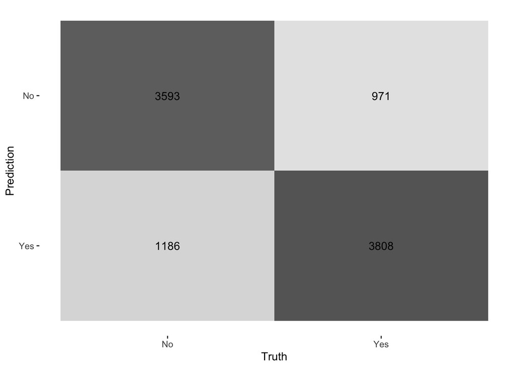

Table 4 displays the number of correct and incorrect predictions, with the specific numbers corresponding to different types of predictions:

- Cell with 3808: We correctly predict that a person will contract heart disease or a heart attack in their life (True Positive).
- Cell with 3593: We correctly predict that a person will not contract heart disease or a heart attack in their life (True regative).
- Cell with 1186: We incorrectly predict that a person will contract heart disease or a heart attack in their life (False Positive).
- Cell with 971: We incorrectly predict that a person will not contract heart disease or a heart attack in their life (False Negative)

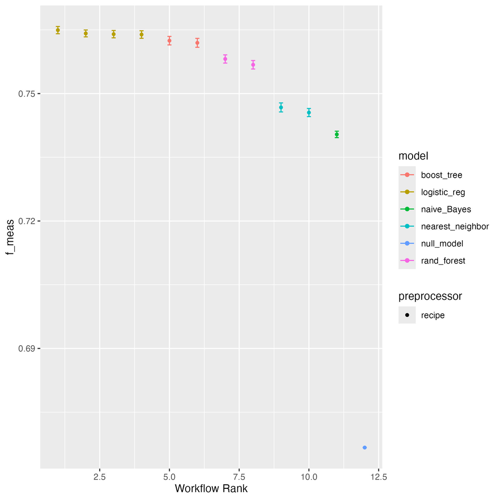

Figure 1: Comparison of the F1 Scores of Different Models

I believe that the final model performs reasonably well. All the complex models perform significantly better than the null and naive Bayes baseline models. Therefore, building a predictive model does pay off. I believe the elastic net performed the best because it provides regularization and therefore prevents against overfitting and multicollinearity, which is especially important for my dataset because many of the predictor variables are correlated with each other.

## Conclusion

This study aimed to predict whether an individual will experience a heart attack or heart disease based on health-related risk behaviors and chronic conditions. By addressing class imbalance and selecting appropriate models, I was able to identify that the elastic net model with a complex recipe performed the best, achieving an overall score of 76.9% for the F1 measure (the original evaluation metric I used to determine which model performed the best). It also demonstrated strong discriminatory ability (ROC AUC, aka Receiver Operating Characteristic - Area Under the Curve, = 0.850), reinforcing its potential in predictive healthcare applications. I am excited (although slightly apprehensive) about the applications of having modelled this; I anticipate sending out a questionnaire to my parents and then using their results to see whether or not they are at predicted to have heart disease!

One key insight from this study is the importance of regularization in predictive modeling. The elastic net model outperformed simpler models by effectively handling multicollinearity and maintaining generalizability. Additionally, interaction terms between High Blood Pressure & High Cholesterol and High Blood Pressure & Diabetes contributed to model complexity and improved performance.

Ultimately, this project demonstrates the value of machine learning in healthcare analytics, particularly in predicting chronic conditions like heart disease. While no predictive model can replace clinical diagnosis, models such as the ones I have fitted in this study can serve as valuable risk assessment tools, helping identify individuals at higher risk and supporting early intervention efforts. I look forward to reading about the latest advancements of modelling and machine learning in healthcare, as I understand this is already happening in the real world but is not without its own biases etc.

This study aimed to predict an individual’s risk of heart disease or heart attack using health-related risk behaviors and chronic conditions. The elastic net model with a complex recipe emerged as the top performer, achieving an F1 score of 76.9% and a ROC AUC of 0.850, demonstrating strong predictive accuracy and discriminatory power. The elastic net model outperformed simpler models by effectively handling multicollinearity and enhancing generalizability. Including interactions between High Blood Pressure & High Cholesterol and High Blood Pressure & Diabetes improved the model’s predictive power by capturing key health-related relationships. These results highlight the model’s potential in healthcare applications for using questinonaire results to identify individuals at higher risk of heart disease and supporting early intervention efforts.

In the future, I would like to build upon this project through the following steps: - Feature Engineering: Adding more interactions or non-linear transformations could capture hidden patterns and improve accuracy. - Alternative Models: Exploring other methods like XGBoost and SVM could further enhance predictive performance. - Evaluation Metric Selection: The ROC AUC of 0.850 was notably higher than the F1 score, indicating the model’s strong discriminatory power. Future studies might consider using ROC AUC as the primary evaluation metric, especially after addressing class imbalance. - External Validation: Testing the model on diverse, real-world datasets from different populations would assess its generalizability and robustness.

### Comment on Generative AI Use

I used generative AI to help me understand the code for a chi squared test for pairs of my predictor variables. I had originally used this link[^1] as a starting point, but was very confused on how to perform a chi squared test for all potential pairs of the predictor variables in my dataset. I asked ChatGPT how to write a function that iterates over all unique pairs of predictor variables to perform a chi squared test and store the values in a dataframe. Similar to the first project, I turned to generative AI when I needed help writing functions, underscoring that this is where I need to work on developing my skills.

<sup>1</sup> GeeksforGeeks. (2023, December 19). ChiSquare Test in R. GeeksforGeeks. https://www.geeksforgeeks.org/chi-square-test-in-r/

## References

Centers for Disease Control and Prevention. (2024, August 5). Heart Disease Prevalence . CDC National Center for Health Statistics. [https://www.cdc.gov/nchs/hus/topics/heart-disease-prevalence.htm.

Centers for Disease Control and Prevention. (2024, November 22). Behavioral Risk Factor Surveillance System. Cdc.gov. https://www.cdc.gov/brfss/index.html

Teboul, A (2023). Heart Disease Health Indicators Dataset. Kaggle. Retrieved February 4, 2022, from https://www.kaggle.com/datasets/alexteboul/heart-disease-health-indicators-dataset/data